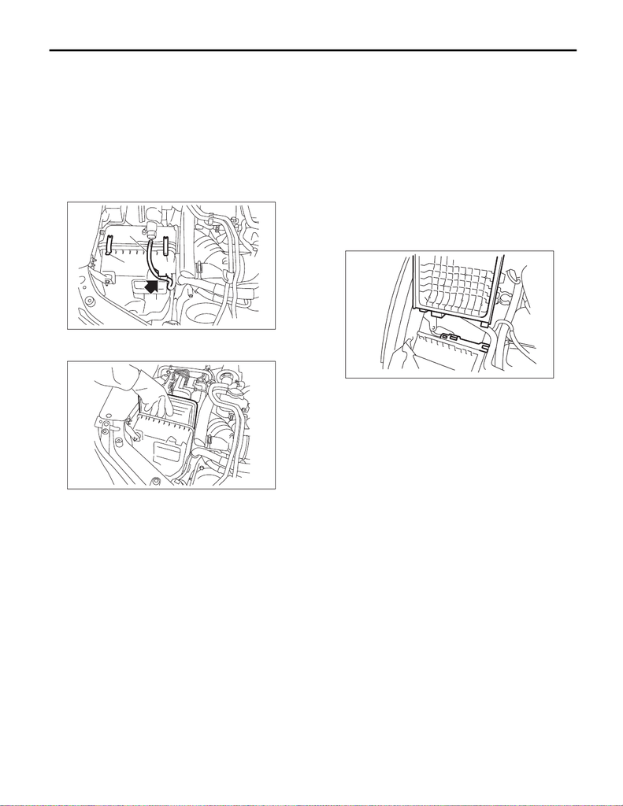

Air Cleaner Element

INTAKE (INDUCTION)

2. Air Cleaner Element

A: REMOVAL

1) Disconnect the ground cable from battery.

2) Remove the air intake duct. <Ref. to IN(STI)-11,

REMOVAL, Air Intake Duct.>

3) Remove the air flow and intake air temperature

sensor harness (A) from the air cleaner case

(front).

4) Remove the clips (B) from the air cleaner case

(front).

5) Open the air cleaner case, and remove the air

cleaner element.

B: INSTALLATION

Install in the reverse order of removal.

CAUTION:

Be sure to use SUBARU genuine air cleaner el-

ement depending on the engine type when re-

placing the air cleaner elements. Using other air

cleaner element may affect the engine perfor-

mance.

NOTE:

• Check that there are no foreign objects in the air

cleaner case.

• When setting the air cleaner case (rear), align

the protrusion of the air cleaner case (rear) to the

air cleaner case (front) to insert.

C: INSPECTION

1) Check that the air cleaner element has no defor-

mation, cracks or other damages.

2) Check the air cleaner element for excessive dirt.

(A)

(B)

(B)